# Case Study 4: Web Scraping

Kelly Carter, Swee K Chew, Volodymyr Orlov, Anjli Solsi

1/25/2020

## Introduction

This case study utilizes data from the race results of the annually held Cherry Blossom Ten-Mile Run in Washington D.C. This analysis focuses on question 11, normalizing each male runner’s time by the fastest time for the runner of the same age. This is accomplished by finding the fastest runner for each year of age from 20 to 80 using the tapply() function. The times are smoothed using the loess() function, and the smoothed times are found using predict(). Using the smoothed times, normalization is applied to each run time. Then, various plots are used to compare the distribution of the age-normalized times for the runners in 1999 and 2012. The same process is then repeated for the women. In the end, there are comparisons between the women in 1999 and 2012 as well as the men in 1999 and 2012.

## Background

The Cherry Blossom Ten-Mile Run has increasingly grown in popularity, attracting tens of thousands of runners aged 9 to 89. The race is held in April, when the cherry trees blossom, having a lottery system which limits the number of runners. The annual results of all years from 1999 to 2012 are posted online, and the data is said to aid in establishing relationships between age and performance. This data includes the runners’ age, name, hometown, and run time all broken down by year.

This case study begins with scraping the data from the web into R. The format of the data varies from year to year. The results are then formatted/cleaned in a way that can be analyzed in R to account for the various discrepancies and mistakes in the data. The authors started with locating each column of data and parsing each record. Header and footer information was ignored and blank information was removed. The times over the years were documented differently, and as the total run time was the focus, that column for each year was identified and organized. Run times were examined for outliers and determination was made as to the plausibility of them. Variables previously noted as NA were also dealt with and either removed or assigned the appropriate value.

## Methods

We used the starter code provided by Professor Slater to scrape the data from the website for men and save it as an RData object. We then used the same set of code, replaced the html links for women and removed the following chunk of code since 2009 data for women was not saved under the node “//div[@class='Section1']” as in men 2009 data. A separate RData object is created for women data.

```
`else if (year == 2009 & sex == "male") {
  # Get preformatted text from <div class="Section1"> element
  # Each line of results is in a <pre> element
  div1 = getNodeSet(doc, "//div[@class='Section1']")
  pres = getNodeSet(div1[[1]], "//pre")
  els = sapply(pres, xmlValue)
}`
```

```r
#load the r datasets
load("cbMen.rda")
head(cbMen)
```

```
##        year sex                   name                home age  runTime
## 1999.1 1999   M Worku Bikila           Ethiopia             28 46.98333
## 1999.2 1999   M Lazarus Nyakeraka      Kenya                24 47.01667
## 1999.3 1999   M James Kariuki          Kenya                27 47.05000
## 1999.4 1999   M William Kiptum         Kenya                28 47.11667
## 1999.5 1999   M Joseph Kimani          Kenya                26 47.51667
## 1999.6 1999   M Josphat Machuka        Kenya                25 47.55000
```

```r
dim(cbMen)
```

```
## [1] 70070     6
```

```r
load("cbWomen.rda")
head(cbWomen)
```

```
##        year sex                   name                home age  runTime
## 1999.1 1999   F Jane Omoro             Kenya                26 53.61667
## 1999.2 1999   F Jane Ngotho            Kenya                29 53.63333
## 1999.3 1999   F Lidiya Grigoryeva      Russia               NA 53.66667
## 1999.4 1999   F Eunice Sagero          Kenya                20 53.91667
## 1999.5 1999   F Alla Zhilyayeva        Russia               29 54.13333
## 1999.6 1999   F Teresa Wanjiku         Kenya                24 54.16667
```

```r
dim(cbWomen)
```

```
## [1] 75971     6
```

### Analysis for Male Runners

The summary statistics below show that the minimum age is 0 and there are 21 records with missing age value. In addition, the minimum run time is 1.5. Since it is a 10-mile race, it is not possible for someone to finish the race in just over a minute. Upon further investigation, the record comes from 2001 data and when we check the source data, it seems like only the first three digits of the net time was recorded for the runner name, Peter HUI, the remaining information is missing. Since it seems to be an error, we will remove that single record from the dataset.

The new summary statistics now show the minimum run time to be over 45 minutes, which sounds reasonable.

```r
summary(cbMen)
```

```
##       year          sex                name               home
##  Min.   :1999   Length:70070       Length:70070       Length:70070
##  1st Qu.:2004   Class :character   Class :character   Class :character
##  Median :2007   Mode  :character   Mode  :character   Mode  :character
##  Mean   :2007
##  3rd Qu.:2010
##  Max.   :2012
##
##       age           runTime
##  Min.   : 0.00   Min.   :  1.50
##  1st Qu.:30.00   1st Qu.: 77.23
##  Median :37.00   Median : 86.53
##  Mean   :38.61   Mean   : 87.48
##  3rd Qu.:46.00   3rd Qu.: 96.60
##  Max.   :89.00   Max.   :175.60
##  NA's   :21
```

```r
cbMen[cbMen$runTime<=1.5, ]
```

```
##           year sex                   name                home age runTime
## 2001.2250 2001   M Peter HUI              Silver Spring MD     70     1.5
```

```r
#drop Peter HUI with 1.5 runTime (2001)
cbMen <- cbMen[cbMen$runTime>1.5, ]
summary(cbMen)
```

```
##       year          sex                name               home
##  Min.   :1999   Length:70069       Length:70069       Length:70069
##  1st Qu.:2004   Class :character   Class :character   Class :character
##  Median :2007   Mode  :character   Mode  :character   Mode  :character
##  Mean   :2007
##  3rd Qu.:2010
##  Max.   :2012
##
##       age           runTime
##  Min.   : 0.00   Min.   : 45.25
##  1st Qu.:30.00   1st Qu.: 77.23
##  Median :37.00   Median : 86.53
##  Mean   :38.61   Mean   : 87.48
##  3rd Qu.:46.00   3rd Qu.: 96.60
##  Max.   :89.00   Max.   :175.60
##  NA's   :21
```

Here, we try to find the fastest runner’s run time for each year of age from 20 to 80. We then plot the fastest run time vs age and find the appropriate hyperparameters for smoothing the times by using loess curve fitting (Figure 1). For this data, the span value of 0.25 seems to be appropriate.

```r
#to plot age vs run time, and pick the span value
fastestRunTime_Men = with(cbMen[cbMen$age >= 20 & cbMen$age <=80, ], tapply(runTime, list(age), FUN = function(x) min(x)))
fastestRunTime_Men = data.frame(fastestRunTime_Men)
age=20:80
fastestRunTime_Men = cbind(age,fastestRunTime_Men)
names(fastestRunTime_Men) <- c("age","runTime")
#Smooth using LOESS
loessResults <- loess(runTime ~ age, data=fastestRunTime_Men, span=0.25, degree=2)
loessSmoothed <- predict(loessResults)
loessSmoothed
```

```
##  [1] 45.49808 45.64907 45.78903 45.91637 46.03459 46.14028 46.24590 46.33140
##  [9] 46.32348 46.30984 46.31477 46.36138 46.41460 46.56818 46.99073 47.54415
## [17] 48.37450 49.23994 49.89339 50.54256 51.12066 51.69388 52.36911 53.03777
## [25] 53.80193 54.53029 55.05981 55.45303 55.57333 55.56147 55.71254 56.10333
## [33] 56.50388 56.81482 57.22622 57.91360 58.63862 59.31391 59.94254 60.36896
## [41] 60.88000 61.37374 61.98053 63.25986 64.90233 66.40040 67.60388 68.74128
## [49] 69.49124 70.28858 72.05050 73.72543 74.73323 75.55842 75.77795 76.09687
## [57] 76.93258 77.91052 79.17937 80.66975 82.39726
```

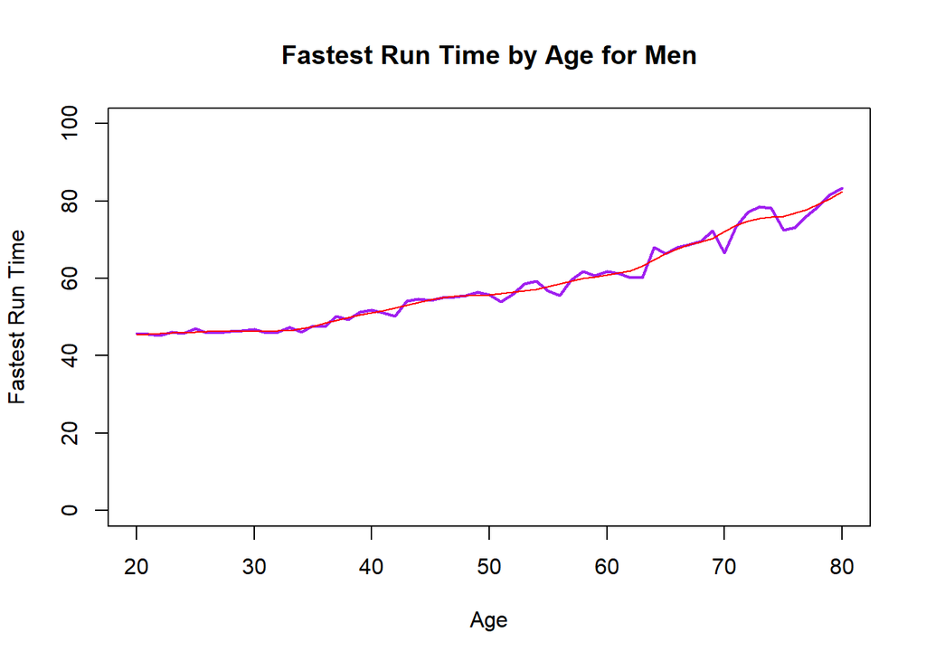

Figure 1: The purple line shows the fastest run time for each year of age from 20 to 80 for men. The red line indicates the loess smoothed times using span of 0.25.

```r
plot(runTime ~ age, data = fastestRunTime_Men,
     xlab = "Age",
     ylab = "Fastest Run Time",
     col = "purple",
     lwd = 2,
     ylim = c(0,100),
     type= "l",
     main = "Fastest Run Time by Age for Men")

lines(loessSmoothed, x=fastestRunTime_Men$age, col="red", type='l')
```

We then create a function to normalize each male runner’s time by the calculated smoothed time of the same age. We add two new columns to the men dataset, *minRunTime* and *normalizedRunTime*. To normalize run time we use this simple formula:

$$\begin{equation}
\tag{1}
newRunTime = \frac{runTime}{bestRunTime}
\end{equation}$$

where $newRunTime$, $runTime$, $bestRunTime$ are normalized, original and fastest runtime for a given age respectively.

```r
#Normalization (Men)
normalizeRunTime <- function(df) {
   #calculate the fastest time for each age 20-80
   fastestRunTime = with(df[df$age >= 20 & df$age <=80, ], tapply(runTime, list(age), FUN = function(x) min(x)))

   #Smooth using LOESS
   time <- unname(fastestRunTime)
   age <- as.integer(names(fastestRunTime))
   loessResults <- loess(time ~ age, span=0.25, degree=2)
   loessSmoothed <- predict(loessResults)
   loessSmoothed

   #Normalize runtime
   resultDf = data.frame(age=as.double(names(fastestRunTime)), minRunTime=loessSmoothed, row.names=NULL)
   resultDf = merge(df, resultDf, by="age")
   resultDf$normalizedRunTime <- resultDf$runTime / resultDf$minRunTime

   return(resultDf)
}
cbMen <- normalizeRunTime(cbMen)
summary(cbMen)
```

```
##       age             year          sex                name
##  Min.   :20.00   Min.   :1999   Length:69363       Length:69363
##  1st Qu.:30.00   1st Qu.:2004   Class :character   Class :character
##  Median :37.00   Median :2007   Mode  :character   Mode  :character
##  Mean   :38.82   Mean   :2007
##  3rd Qu.:46.00   3rd Qu.:2010
##  Max.   :80.00   Max.   :2012
##      home              runTime         minRunTime    normalizedRunTime
##  Length:69363       Min.   : 45.25   Min.   :45.50   Min.   :0.9234
##  Class :character   1st Qu.: 77.28   1st Qu.:46.33   1st Qu.:1.5053
##  Mode  :character   Median : 86.57   Median :49.24   Median :1.7042
##                     Mean   : 87.51   Mean   :50.88   Mean   :1.7320
##                     3rd Qu.: 96.60   3rd Qu.:55.06   3rd Qu.:1.9306
##                     Max.   :175.60   Max.   :82.40   Max.   :3.3665
```

In order to compare the distribution of the age-normalized times for the male runners in 1999 and 2012, we generate summary statistics, density plots, and quantile–quantile plots.

**Summary Statistics**

```r
summary(cbMen[cbMen$year == 1999, ]$normalizedRunTime)
```

```
##    Min. 1st Qu.  Median    Mean 3rd Qu.    Max.
##  0.9514  1.4474  1.6266  1.6444  1.8270  2.9203
```

```r
summary(cbMen[cbMen$year == 2012, ]$normalizedRunTime)
```

```
##    Min. 1st Qu.  Median    Mean 3rd Qu.    Max.
##  0.9479  1.5294  1.7369  1.7647  1.9700  3.1024
```

The summary statistics for 1999 and 2012 indicate that the normalized run times for 2012 have a slightly larger spread/range than 1999 and the 1999 mean run time of 1.64 is smaller than the 2012’s mean run time of 1.76. **Density Plots**

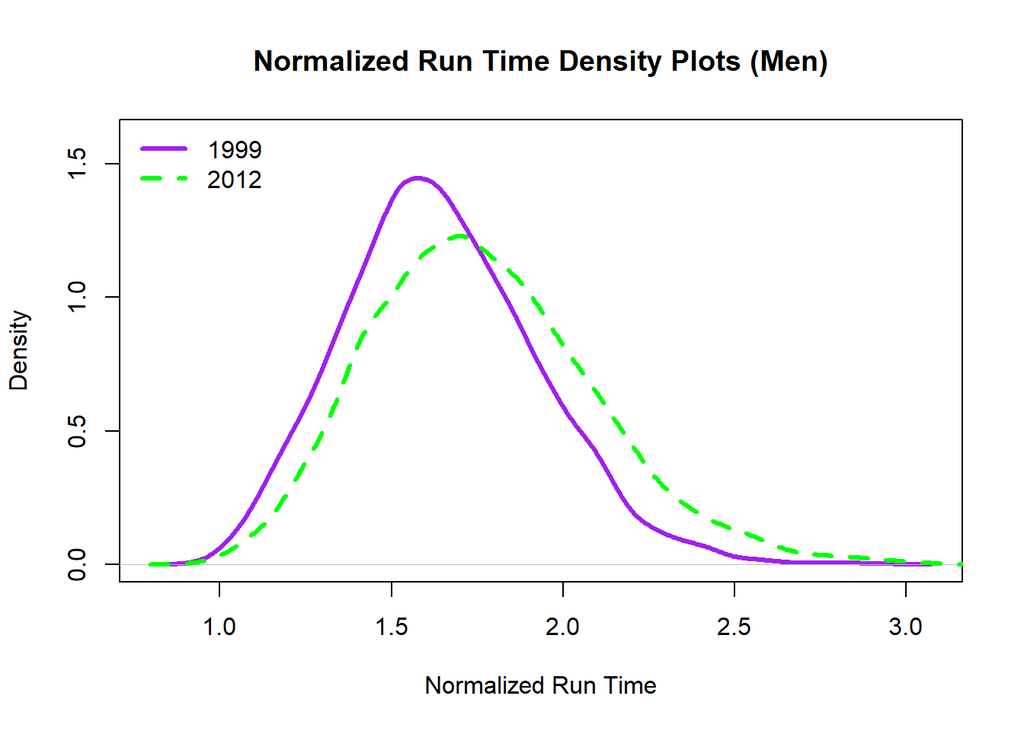

Figure 2: Normalized run time density plots for men. The 1999 density plot is shown in purple and the 2012 density plot is shown in green.

```r
plot(density(cbMen[cbMen$year == 1999, ]$normalizedRunTime, na.rm = TRUE),
     xlab = "Normalized Run Time",
     col = "purple",
     lwd = 3,
     ylim = c(0, 1.6),
     main = "Normalized Run Time Density Plots (Men)")
lines(density(cbMen[cbMen$year == 2012, ]$normalizedRunTime, na.rm = TRUE),
      lwd = 3,
      lty = 2,
      col="green")
legend("topleft", col = c("purple", "green"), lty= 1:2, lwd = 3,
       legend = c("1999", "2012"), bty = "n")
```

When comparing the density plots of the age-normalized times for the male runners in 1999 and 2012 as seen in Figure 2, it appears that participants in 1999 were overall able to finish the race in a shorter time period than in 2012 as the density plot for 2012 is more spread out and has a wider range.

**Q-Q Plot**

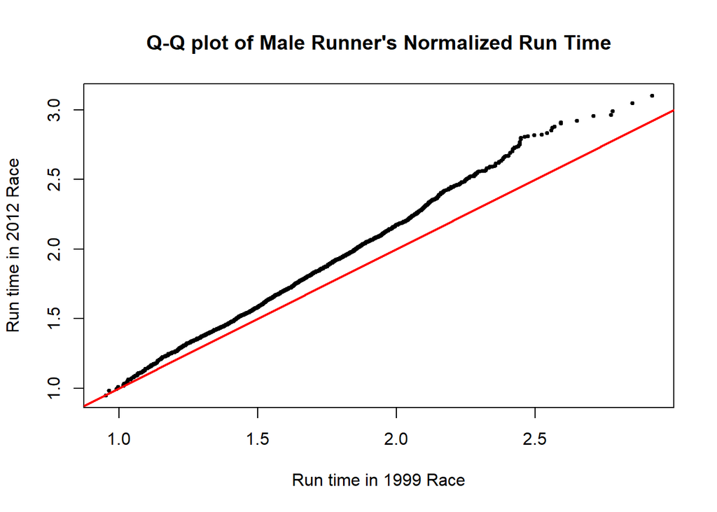

Figure 3: Q-Q plot of normalized run time for male which plots the 1999 normalized run time against the 2012 normalized run time.

```r
qqplot(cbMen[cbMen$year == 1999, ]$normalizedRunTime, cbMen[cbMen$year == 2012, ]$normalizedRunTime, pch = 19, cex = 0.5,
       xlab = "Run time in 1999 Race",
       ylab = "Run time in 2012 Race",
       main = "Q-Q plot of Male Runner's Normalized Run Time")
abline(a =0, b = 1, col="red", lwd = 2)
```

The Q-Q plot in Figure 3 shows a high level of deviation from a straight line. The Q-Q plot here compares the quantiles of the 1999 and 2012 normalized run times to see whether they have the same distribution. Based on the plot, it does not appear that they do.

### Analysis for Female Runners

The summary statistics for female runners below show that the minimum age is 0 and there are 21 records with missing age value as well. The minimum run time is over 51 minutes, which sounds reasonable and is higher than the minimum run time for men (~45 mins).

```r
summary(cbWomen)
```

```
##       year          sex                name               home
##  Min.   :1999   Length:75971       Length:75971       Length:75971
##  1st Qu.:2005   Class :character   Class :character   Class :character
##  Median :2008   Mode  :character   Mode  :character   Mode  :character
##  Mean   :2007
##  3rd Qu.:2010
##  Max.   :2012
##
##       age           runTime
##  Min.   : 0.00   Min.   : 51.73
##  1st Qu.:27.00   1st Qu.: 88.53
##  Median :32.00   Median : 97.33
##  Mean   :33.85   Mean   : 98.09
##  3rd Qu.:39.00   3rd Qu.:106.78
##  Max.   :87.00   Max.   :177.52
##  NA's   :21
```

Similarly, we try to find the fastest runner’s run time for each year of age from 20 to 80 as we did for the men dataset. We then plot the fastest run time vs age and find the appropriate hyperparameters for smoothing the times by using loess curve fitting as shown in Figure 4. For this data, the span value of 0.25 seems to be appropriate as well, although here is a high level of noise for the last few data points. That is because there are not many female runners who are above 75, there is only one female runner at each age 77, 78, and 80.

```r
#to plot age vs run time, and pick the span value
fastestRunTime_Women = with(cbWomen[cbWomen$age >= 20 & cbWomen$age <=80, ], tapply(runTime, list(age), FUN = function(x) min(x)))
fastestRunTime_Women = data.frame(fastestRunTime_Women)
age=c(20:78,80)
fastestRunTime_Women = cbind(age,fastestRunTime_Women)
names(fastestRunTime_Women) <- c("age","runTime")
#Smooth using LOESS
loessResults <- loess(runTime ~ age, data=fastestRunTime_Women, span=0.25, degree=2)
loessSmoothed <- predict(loessResults)
loessSmoothed
```

```
##  [1]  53.01105  52.95188  52.93148  52.92576  52.93291  52.94588  53.04398
##  [8]  53.14918  53.10531  53.01834  52.79043  52.59263  52.60598  52.71877
## [15]  53.02452  53.53645  54.21030  55.25793  56.40013  57.46240  58.45836
## [22]  59.24002  59.95328  60.48009  60.93594  61.39468  61.85919  62.48660
## [29]  63.15374  63.67766  63.90234  64.11587  64.33010  64.61903  65.31207
## [36]  66.11161  67.00832  67.93392  68.39315  69.01155  70.13425  71.49776
## [43]  73.55316  76.02499  78.13894  79.59683  80.93547  82.02904  83.05508
## [50]  84.49857  86.01579  85.63906  86.35404  90.67204  96.39553 103.63033
## [57] 112.04337 121.44277 132.03817 156.82045
```

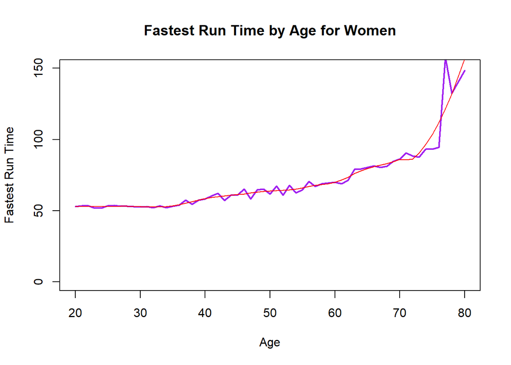

Figure 4: The purple line shows the fastest run time for each year of age from 20 to 80 for women. The red line indicates the loess smoothed times using span of 0.25.

```r
plot(runTime ~ age, data = fastestRunTime_Women,
     xlab = "Age",
     ylab = "Fastest Run Time",
     col = "purple",
     lwd = 2,
     type = "l",
     ylim = c(0,150),
     main = "Fastest Run Time by Age for Women")

lines(loessSmoothed, x=fastestRunTime_Women$age, col="red", type='l')
```

We then create a function to normalize each female runner’s time by the calculated smoothed time of the same age. We add two new columns to the women dataset, *minRunTime* and *normalizedRunTime*, where values of *normalizedRunTime* are calculated using formula *(1)*.

```r
#Normalization (Women)
normalizeRunTime <- function(df) {
   #calculate the fastest time for each age 20-80
   fastestRunTime = with(df[df$age >= 20 & df$age <=80, ], tapply(runTime, list(age), FUN = function(x) min(x)))

   #Smooth using LOESS
   time <- unname(fastestRunTime)
   age <- as.integer(names(fastestRunTime))
   loessResults <- loess(time ~ age, span=0.25)
   loessSmoothed <- predict(loessResults)
   loessSmoothed

   #Normalize runtime
   resultDf = data.frame(age=as.double(names(fastestRunTime)), minRunTime=loessSmoothed, row.names=NULL)
   resultDf = merge(df, resultDf, by="age")
   resultDf$normalizedRunTime <- resultDf$runTime / resultDf$minRunTime

   return(resultDf)
}
cbWomen <- normalizeRunTime(cbWomen)
summary(cbWomen)
```

```
##       age             year          sex                name
##  Min.   :20.00   Min.   :1999   Length:75273       Length:75273
##  1st Qu.:27.00   1st Qu.:2005   Class :character   Class :character
##  Median :32.00   Median :2008   Mode  :character   Mode  :character
##  Mean   :33.99   Mean   :2007
##  3rd Qu.:39.00   3rd Qu.:2010
##  Max.   :80.00   Max.   :2012
##      home              runTime         minRunTime     normalizedRunTime
##  Length:75273       Min.   : 51.73   Min.   : 52.59   Min.   :0.8437
##  Class :character   1st Qu.: 88.57   1st Qu.: 52.93   1st Qu.:1.5852
##  Mode  :character   Median : 97.37   Median : 53.11   Median :1.7614
##                     Mean   : 98.11   Mean   : 55.67   Mean   :1.7708
##                     3rd Qu.:106.80   3rd Qu.: 57.46   3rd Qu.:1.9434
##                     Max.   :177.52   Max.   :156.82   Max.   :3.3158
```

In order to compare the distribution of the age-normalized times for the female runners in 1999 and 2012, we generate summary statistics, density plots, and quantile–quantile plots.

**Summary Statistics**

```r
summary(cbWomen[cbWomen$year == 1999, ]$normalizedRunTime)
```

```
##    Min. 1st Qu.  Median    Mean 3rd Qu.    Max.
##   0.966   1.554   1.722   1.715   1.875   2.991
```

```r
summary(cbWomen[cbWomen$year == 2012, ]$normalizedRunTime)
```

```
##    Min. 1st Qu.  Median    Mean 3rd Qu.    Max.
##  0.8992  1.5982  1.7777  1.7891  1.9662  3.0313
```

The summary statistics for 1999 and 2012 also show that the normalized run times for 2012 have a slightly larger spread than 1999. We also noted that the 1999 mean run time is smaller than the 2012’s. The mean run time for 1999 is 1.72 vs 1.79 for 2012.

**Density Plots**

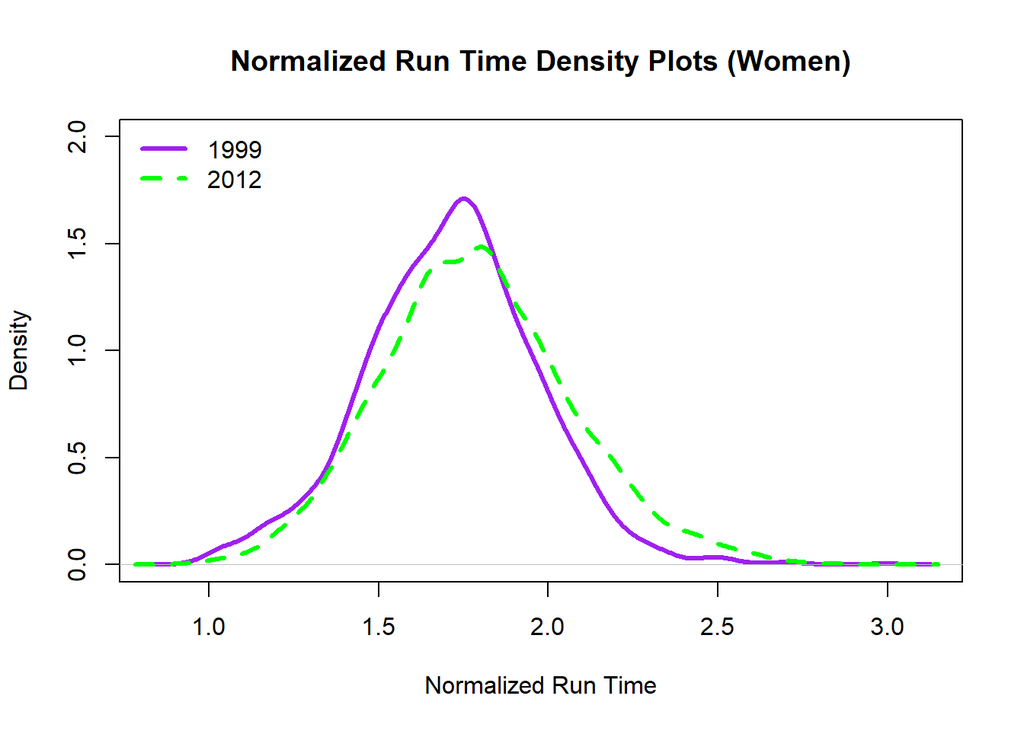

Figure 5: Normalized run time density plots for women. The 1999 density plot is shown in purple and the 2012 density plot is shown in green.

```r
plot(density(cbWomen[cbWomen$year == 1999, ]$normalizedRunTime, na.rm = TRUE),
     xlab = "Normalized Run Time",
     col = "purple",
     lwd = 3,
     ylim = c(0, 2.0),
     main = "Normalized Run Time Density Plots (Women)")
lines(density(cbWomen[cbWomen$year == 2012, ]$normalizedRunTime, na.rm = TRUE),
      lwd = 3,
      lty = 2,
      col="green")
legend("topleft", col = c("purple", "green"), lty= 1:2, lwd = 3,
       legend = c("1999", "2012"), bty = "n")
```

When comparing the distribution of the age-normalized times for the female runners in 1999 and 2012, it appears that overall, participants in 1999 were able to finish the race in shorter time period than the 2012 participants as we can see from the density plot in Figure 5. Similarly to male participants, more female participants finished the race in less time in 1999 than 2012, the density plot for 2012 is more spread out and it has a wider range. However, the density plots between 1999 and 2012 are more similar to one another than those for the male runners.

**Q-Q Plot**

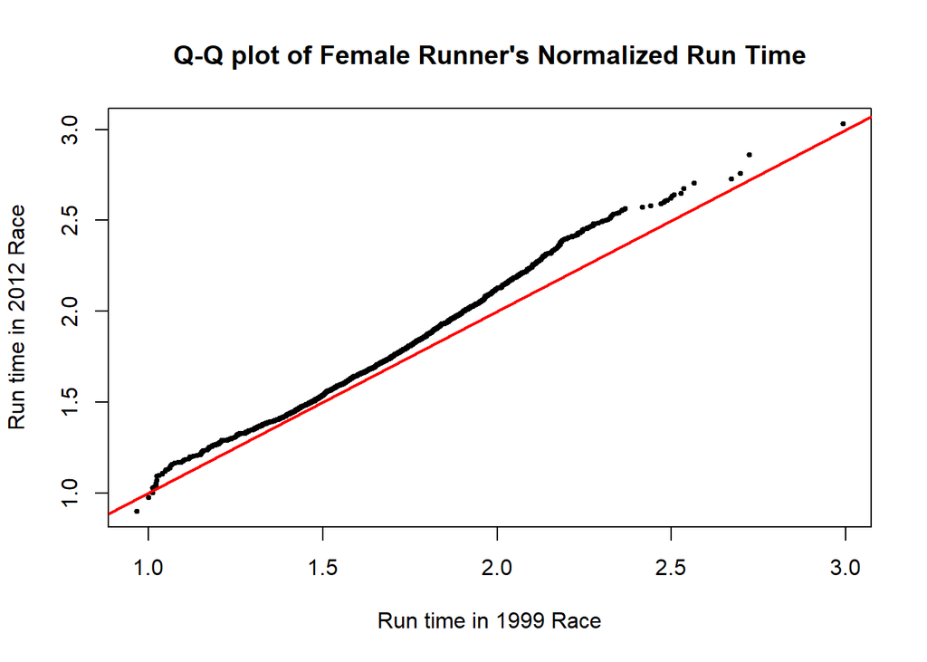

```r
qqplot(cbWomen[cbWomen$year == 1999, ]$normalizedRunTime, cbWomen[cbWomen$year == 2012, ]$normalizedRunTime, pch = 19, cex = 0.5,
       xlab = "Run time in 1999 Race",
       ylab = "Run time in 2012 Race",
       main = "Q-Q plot of Female Runner's Normalized Run Time")
abline(a =0, b = 1, col="red", lwd = 2)
```

The Q-Q plot in Figure 6 also shows less deviation from a straight line than the one for the male runners. Based on the plot, we can say that the two sets of quantiles for 1999 and 2012 women data have a similar distribution.

**Density Plots: Women vs Men**

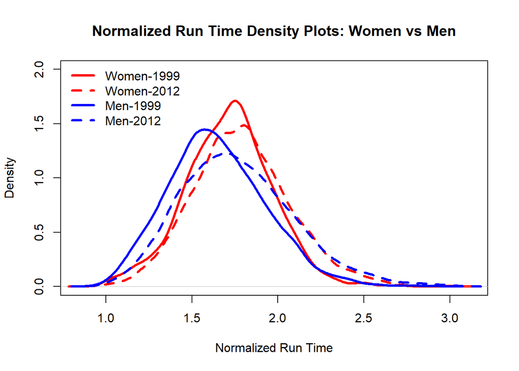

Figure 7: Normalized run time density plots for women and men. The 1999 density plot for women is shown in solid red and the 2012 density plot in dotted red. Blue color indicates the density plots for men respectively.

```r
plot(density(cbWomen[cbWomen$year == 1999, ]$normalizedRunTime, na.rm = TRUE),
     xlab = "Normalized Run Time",
     col = "red",
     lwd = 3,
     ylim = c(0, 2.0),
     main = "Normalized Run Time Density Plots: Women vs Men")
lines(density(cbWomen[cbWomen$year == 2012, ]$normalizedRunTime, na.rm = TRUE),
      lwd = 3,
      lty = 2,
      col="red")
lines(density(cbMen[cbMen$year == 1999, ]$normalizedRunTime, na.rm = TRUE),
      lwd = 3,
      lty = 1,
      col="blue")
lines(density(cbMen[cbMen$year == 2012, ]$normalizedRunTime, na.rm = TRUE),
      lwd = 3,
      lty = 2,
      col="blue")
legend("topleft", col = c("red", "red", "blue", "blue"), lty= c(1:2, 1:2), lwd = 3,
       legend = c("Women-1999", "Women-2012", "Men-1999", "Men-2012"), bty = "n")
```

In Figure 7, we can see that the male runners in general finished the race faster than the female runners. The spread is also larger for men than women. The 2012 male density plot seems to have the largest spread, and more female runners finished the race around the mean run time in both 1999 and 2012 compared to its counterparts.

## Conclusion

Overall, we found that the female run times distribution for 1999 and 2012 are more similar the males run times distribution for the same years. However, we did find several similarities between male and female run times in 1999 and in 2012.

We found that in 1999 for both male and female runners that the overall spread was smaller, more participants finished the race in less time, and the mean and median run times were smaller than in 2012. Further work could include comparing the age density for between 1999 and 2012 for men and women to see if the faster run times in 1999 could be due to younger participants.

The tighter age range for the female runners overall could contribute to why 1999 and 2012 have similar distributions. Further work could include re-running this analysis with a smaller age range to see if the same conclusion is reached. This would additionally fix the issues previously found in Figure 4.

## Sources

[1] D. Lang and D. Nolan, Data Science in R: A Case Studies Approach to Computation Reasoning and Problem Solving. New York, New York: CRC Press.

[2] Deborah Nolan and Duncan Temple Lang, “Case Studies in Data Science with R”. University of California, Berkeley and University of California, Davis. 2015. http://www.rdatasciencecases.org